[figure not shown]

# **Business Analytics Practicum (MGT6214)**

Instructor: Zhaohu(Jonathan) Fan

For additional information contact him (jonathan.fan@scheller.gatech.edu)

> This demonstration is appropriate for those with little or no programming experience. This session will include hands-on activities, and there will be time at the end for questions.

> In this Google Colab Notebook, you are going to mimic the steps illustrated from the demonstration in creating your first trading strategy - Trend following trading strategy.

*Useful intro about [Colab](https://colab.research.google.com/notebooks/welcome.ipynb)*

*Useful links [Load CSV files into Colab](https://towardsdatascience.com/3-ways-to-load-csv-files-into-colab-7c14fcbdcb92)*

# Build a simple trading strategy

## Step 1: Load the Dependencies

> This section loads some required libraries used in this notebook: **numpy**, **pandas**, **matplotlib**
- [Numpy](https://www.numpy.org/) is an array manipulation library, used for linear algebra, Fourier transform, and random number capabilities.
- [Pandas](https://pandas.pydata.org/) is a library for data manipulation and data analysis.
- [Matplotlib](https://matplotlib.org/) is a library which generates figures and provides graphical user interface toolkit.

```python
import numpy as np
import pandas as pd
import matplotlib.pyplot as plt
%matplotlib inline
```

## Step 2: Import FB's stock data

> - Upload CSV file manually

```python
from google.colab import files
uploaded = files.upload()
```

Upload widget is only available when the cell has been executed in the current browser session. Please rerun this cell to enable.

```
Saving facebook.csv to facebook.csv
```

```
# This is formatted as code
```

It will prompt you to select a file. Click on “Choose Files” then select and upload the file. Wait for the file to be 100% uploaded. You should see the name of the file once Colab has uploaded it.

```python
#import FB's stock data
import io
fb1 = pd.read_csv(io.BytesIO(uploaded['facebook.csv']))
fb1
```

|  | Date | Open | High | Low | Close | Adj Close | Volume |
| --- | --- | --- | --- | --- | --- | --- | --- |
| 0 | 2014-12-31 | 20.400000 | 20.510000 | 19.990000 | 20.049999 | 19.459270 | 4157500 |
| 1 | 2015-01-02 | 20.129999 | 20.280001 | 19.809999 | 20.129999 | 19.536913 | 2842000 |
| 2 | 2015-01-05 | 20.129999 | 20.190001 | 19.700001 | 19.790001 | 19.206934 | 4948800 |
| 3 | 2015-01-06 | 19.820000 | 19.840000 | 19.170000 | 19.190001 | 18.624611 | 4944100 |
| 4 | 2015-01-07 | 19.330000 | 19.500000 | 19.080000 | 19.139999 | 18.576082 | 8045200 |
| ... | ... | ... | ... | ... | ... | ... | ... |
| 775 | 2018-01-30 | 241.110001 | 246.419998 | 238.410004 | 242.720001 | 242.720001 | 14270800 |
| 776 | 2018-01-31 | 245.770004 | 249.270004 | 244.449997 | 245.800003 | 245.800003 | 11964400 |
| 777 | 2018-02-01 | 238.520004 | 246.899994 | 238.059998 | 240.500000 | 240.500000 | 12980600 |
| 778 | 2018-02-02 | 237.000000 | 237.970001 | 231.169998 | 233.520004 | 233.520004 | 17961600 |
| 779 | 2018-02-05 | 227.000000 | 233.229996 | 205.000000 | 213.699997 | 213.699997 | 28869000 |

780 rows × 7 columns

```python
fb = pd.DataFrame(fb1)
fb
```

|  | Date | Open | High | Low | Close | Adj Close | Volume |
| --- | --- | --- | --- | --- | --- | --- | --- |
| 0 | 2014-12-31 | 20.400000 | 20.510000 | 19.990000 | 20.049999 | 19.459270 | 4157500 |
| 1 | 2015-01-02 | 20.129999 | 20.280001 | 19.809999 | 20.129999 | 19.536913 | 2842000 |
| 2 | 2015-01-05 | 20.129999 | 20.190001 | 19.700001 | 19.790001 | 19.206934 | 4948800 |
| 3 | 2015-01-06 | 19.820000 | 19.840000 | 19.170000 | 19.190001 | 18.624611 | 4944100 |
| 4 | 2015-01-07 | 19.330000 | 19.500000 | 19.080000 | 19.139999 | 18.576082 | 8045200 |
| ... | ... | ... | ... | ... | ... | ... | ... |
| 775 | 2018-01-30 | 241.110001 | 246.419998 | 238.410004 | 242.720001 | 242.720001 | 14270800 |
| 776 | 2018-01-31 | 245.770004 | 249.270004 | 244.449997 | 245.800003 | 245.800003 | 11964400 |
| 777 | 2018-02-01 | 238.520004 | 246.899994 | 238.059998 | 240.500000 | 240.500000 | 12980600 |
| 778 | 2018-02-02 | 237.000000 | 237.970001 | 231.169998 | 233.520004 | 233.520004 | 17961600 |
| 779 | 2018-02-05 | 227.000000 | 233.229996 | 205.000000 | 213.699997 | 213.699997 | 28869000 |

780 rows × 7 columns

## Step 2': Import Microsoft's stock data (microsoft.csv)

- Read CSV from Google Drive

```python
from google.colab import drive
drive.mount('/content/drive')
```

click on the charcoal > on the top left of the notebook and click on Files. Locate the data folder you created earlier and find your data. Right-click on your data and select Copy Path. Store this copied path into a variable and you are ready to go.

```python
path = "/content/microsoft.csv"
df_microsoft = pd.read_csv(path)
df_microsoft
```

[output not shown]

## Step 3: Add two columns - MA10 and MA50

```python
fb['MA10'] = fb['Close'].rolling(10).mean()
fb['MA50'] = fb['Close'].rolling(50).mean()
fb.head()
```

|  | Date | Open | High | Low | Close | Adj Close | Volume | MA10 | MA50 |
| --- | --- | --- | --- | --- | --- | --- | --- | --- | --- |
| 0 | 2014-12-31 | 20.400000 | 20.510000 | 19.990000 | 20.049999 | 19.459270 | 4157500 | NaN | NaN |
| 1 | 2015-01-02 | 20.129999 | 20.280001 | 19.809999 | 20.129999 | 19.536913 | 2842000 | NaN | NaN |
| 2 | 2015-01-05 | 20.129999 | 20.190001 | 19.700001 | 19.790001 | 19.206934 | 4948800 | NaN | NaN |
| 3 | 2015-01-06 | 19.820000 | 19.840000 | 19.170000 | 19.190001 | 18.624611 | 4944100 | NaN | NaN |
| 4 | 2015-01-07 | 19.330000 | 19.500000 | 19.080000 | 19.139999 | 18.576082 | 8045200 | NaN | NaN |

## Step 4: Use dropna to remove any "Not a Number" data

```python
fb = fb.dropna()
fb.head()
```

|  | Date | Open | High | Low | Close | Adj Close | Volume | MA10 | MA50 |
| --- | --- | --- | --- | --- | --- | --- | --- | --- | --- |
| 49 | 2015-03-13 | 22.559999 | 22.760000 | 22.250000 | 22.700001 | 22.116024 | 8982200 | 22.648 | 21.0174 |
| 50 | 2015-03-16 | 22.879999 | 23.110001 | 22.730000 | 22.969999 | 22.379078 | 5923900 | 22.685 | 21.0758 |
| 51 | 2015-03-17 | 22.920000 | 23.260000 | 22.760000 | 23.250000 | 22.651876 | 7497500 | 22.792 | 21.1382 |
| 52 | 2015-03-18 | 23.250000 | 23.370001 | 22.660000 | 22.870001 | 22.281652 | 10337600 | 22.836 | 21.1998 |
| 53 | 2015-03-19 | 22.950001 | 23.299999 | 22.780001 | 23.219999 | 22.622650 | 7768900 | 22.872 | 21.2804 |

## Step 5: Add a new column "Shares", if MA10>MA50, denote as 1 (long one share of stock), otherwise, denote as 0 (do nothing)

```python
fb['Shares'] = [1 if fb.loc[ei, 'MA10']>fb.loc[ei, 'MA50'] else 0 for ei in fb.index]
fb
```

|  | Date | Open | High | Low | Close | Adj Close | Volume | MA10 | MA50 | Shares |
| --- | --- | --- | --- | --- | --- | --- | --- | --- | --- | --- |
| 49 | 2015-03-13 | 22.559999 | 22.760000 | 22.250000 | 22.700001 | 22.116024 | 8982200 | 22.648000 | 21.017400 | 1 |
| 50 | 2015-03-16 | 22.879999 | 23.110001 | 22.730000 | 22.969999 | 22.379078 | 5923900 | 22.685000 | 21.075800 | 1 |
| 51 | 2015-03-17 | 22.920000 | 23.260000 | 22.760000 | 23.250000 | 22.651876 | 7497500 | 22.792000 | 21.138200 | 1 |
| 52 | 2015-03-18 | 23.250000 | 23.370001 | 22.660000 | 22.870001 | 22.281652 | 10337600 | 22.836000 | 21.199800 | 1 |
| 53 | 2015-03-19 | 22.950001 | 23.299999 | 22.780001 | 23.219999 | 22.622650 | 7768900 | 22.872000 | 21.280400 | 1 |
| ... | ... | ... | ... | ... | ... | ... | ... | ... | ... | ... |
| 775 | 2018-01-30 | 241.110001 | 246.419998 | 238.410004 | 242.720001 | 242.720001 | 14270800 | 235.692003 | 210.030001 | 1 |
| 776 | 2018-01-31 | 245.770004 | 249.270004 | 244.449997 | 245.800003 | 245.800003 | 11964400 | 237.800003 | 210.713801 | 1 |
| 777 | 2018-02-01 | 238.520004 | 246.899994 | 238.059998 | 240.500000 | 240.500000 | 12980600 | 239.406003 | 211.296601 | 1 |
| 778 | 2018-02-02 | 237.000000 | 237.970001 | 231.169998 | 233.520004 | 233.520004 | 17961600 | 239.747003 | 211.685401 | 1 |
| 779 | 2018-02-05 | 227.000000 | 233.229996 | 205.000000 | 213.699997 | 213.699997 | 28869000 | 237.748003 | 211.638401 | 1 |

731 rows × 10 columns

## Step 6: Add a new column "Profit" using List Comprehension, for any rows in fb, if Shares=1, the profit is calculated as the close price of tomorrow - the close price of today. Otherwise the profit is 0.

```python
fb['Close1'] = fb['Close'].shift(-1)
fb
fb['Profit'] = [fb.loc[ei, 'Close1'] - fb.loc[ei, 'Close'] if fb.loc[ei, 'Shares']==1 else 0 for ei in fb.index]
fb
```

|  | Date | Open | High | Low | Close | Adj Close | Volume | MA10 | MA50 | Shares | Close1 | Profit |
| --- | --- | --- | --- | --- | --- | --- | --- | --- | --- | --- | --- | --- |
| 49 | 2015-03-13 | 22.559999 | 22.760000 | 22.250000 | 22.700001 | 22.116024 | 8982200 | 22.648000 | 21.017400 | 1 | 22.969999 | 0.269998 |
| 50 | 2015-03-16 | 22.879999 | 23.110001 | 22.730000 | 22.969999 | 22.379078 | 5923900 | 22.685000 | 21.075800 | 1 | 23.250000 | 0.280001 |
| 51 | 2015-03-17 | 22.920000 | 23.260000 | 22.760000 | 23.250000 | 22.651876 | 7497500 | 22.792000 | 21.138200 | 1 | 22.870001 | -0.379999 |
| 52 | 2015-03-18 | 23.250000 | 23.370001 | 22.660000 | 22.870001 | 22.281652 | 10337600 | 22.836000 | 21.199800 | 1 | 23.219999 | 0.349998 |
| 53 | 2015-03-19 | 22.950001 | 23.299999 | 22.780001 | 23.219999 | 22.622650 | 7768900 | 22.872000 | 21.280400 | 1 | 23.469999 | 0.250000 |
| ... | ... | ... | ... | ... | ... | ... | ... | ... | ... | ... | ... | ... |
| 775 | 2018-01-30 | 241.110001 | 246.419998 | 238.410004 | 242.720001 | 242.720001 | 14270800 | 235.692003 | 210.030001 | 1 | 245.800003 | 3.080002 |
| 776 | 2018-01-31 | 245.770004 | 249.270004 | 244.449997 | 245.800003 | 245.800003 | 11964400 | 237.800003 | 210.713801 | 1 | 240.500000 | -5.300003 |
| 777 | 2018-02-01 | 238.520004 | 246.899994 | 238.059998 | 240.500000 | 240.500000 | 12980600 | 239.406003 | 211.296601 | 1 | 233.520004 | -6.979996 |
| 778 | 2018-02-02 | 237.000000 | 237.970001 | 231.169998 | 233.520004 | 233.520004 | 17961600 | 239.747003 | 211.685401 | 1 | 213.699997 | -19.820007 |
| 779 | 2018-02-05 | 227.000000 | 233.229996 | 205.000000 | 213.699997 | 213.699997 | 28869000 | 237.748003 | 211.638401 | 1 | NaN | NaN |

731 rows × 12 columns

## Step 7: Plot a graph to show the Profit/Loss

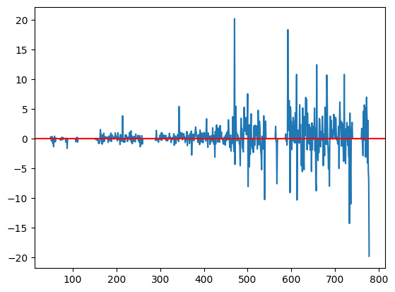

```python
fb['Profit'].plot()
plt.axhline(y=0, color='red')
```

## Step 8: Use .cumsum() to calculate the accumulated wealth over the period

```python
fb['wealth'] = fb['Profit'].cumsum()
fb.head()
```

|  | Date | Open | High | Low | Close | Adj Close | Volume | MA10 | MA50 | Shares | Close1 | Profit | wealth |
| --- | --- | --- | --- | --- | --- | --- | --- | --- | --- | --- | --- | --- | --- |
| 49 | 2015-03-13 | 22.559999 | 22.760000 | 22.250000 | 22.700001 | 22.116024 | 8982200 | 22.648 | 21.0174 | 1 | 22.969999 | 0.269998 | 0.269998 |
| 50 | 2015-03-16 | 22.879999 | 23.110001 | 22.730000 | 22.969999 | 22.379078 | 5923900 | 22.685 | 21.0758 | 1 | 23.250000 | 0.280001 | 0.549999 |
| 51 | 2015-03-17 | 22.920000 | 23.260000 | 22.760000 | 23.250000 | 22.651876 | 7497500 | 22.792 | 21.1382 | 1 | 22.870001 | -0.379999 | 0.170000 |
| 52 | 2015-03-18 | 23.250000 | 23.370001 | 22.660000 | 22.870001 | 22.281652 | 10337600 | 22.836 | 21.1998 | 1 | 23.219999 | 0.349998 | 0.519998 |
| 53 | 2015-03-19 | 22.950001 | 23.299999 | 22.780001 | 23.219999 | 22.622650 | 7768900 | 22.872 | 21.2804 | 1 | 23.469999 | 0.250000 | 0.769998 |

## Step 9: Plot the wealth to show the growth of profit over the period

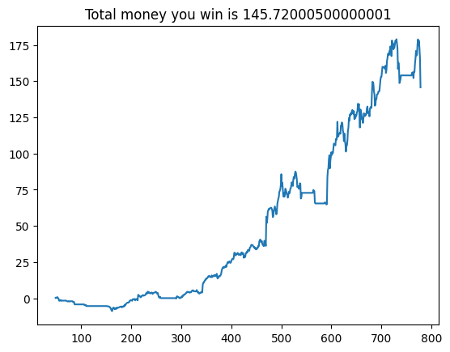

```python
fb['wealth'].plot()
plt.title('Total money you win is {}'.format(fb.loc[fb.index[-2], 'wealth']))
```

# 1: You can create your own simple trading strategy by copying the codes above and modify the codes accordingly using the data of Microsoft (microsoft.csv).

```python
import numpy as np
import pandas as pd
import matplotlib.pyplot as plt
%matplotlib inline
```

```python
%%shell
jupyter nbconvert project_demo.ipynb --to html
```

```
[NbConvertApp] Converting notebook project_demo.ipynb to html
[NbConvertApp] Writing 781347 bytes to project_demo.html
```